# 02. Grammar of Graphics

DSST289: Introduction to Data Science

Author

Erik Fredner

Published

August 30, 2024

## Why visualize data?

Data visualization is a crucial and complex part of data science.

You may have often heard the phrases “numbers don’t lie” or “the data speaks for itself.” These common phrases are at least misleading, and sometimes entirely wrong.

Data visualization is one of the main ways that we can explore, understand, and communicate with data. But it is also a major way that people can be misled (or mislead others) with data.

For example, look at these graphs very quickly, the way you might while skimming a news article:

1. How would you tell the “story” of the plot on the left?
2. How would you tell the “story” of the plot on the right?

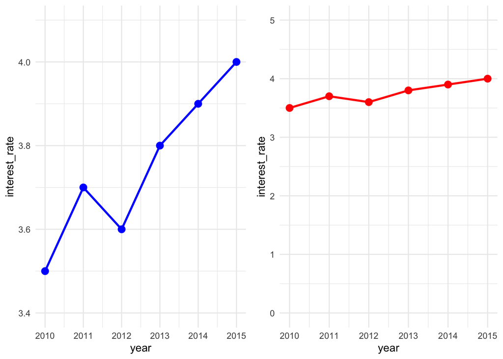

Both of these plots show the same data, but the y-axis is different in each. The first plot has a narrow y-axis (3.4-4.1), which makes the changes in interest rates look more dramatic. The second plot has a broader y-axis (0-5), which makes the changes look less dramatic.

Learning how to do data visualization well is about learning how to make sure that the data is presented in a way that is truthful and informative.

**Note**

For more about the history of data visualization, check out [*Data by Design*](https://dataxdesign.io/).

## Elements of data visualization

Data visualization is an important skill that R is particularly well-designed for. We are going to learn and use the [`ggplot2`](https://ggplot2.tidyverse.org) package for building beautiful and informative graphics. `ggplot2` is part of the `tidyverse`, which is a popular set of R packages that we will be using throughout this course. The graphics above were made with `ggplot`.

The package makes it easy to build fairly complex graphics in a way that is guided by a general theory of data visualization. The only downside is that, because it is built around a theoretical model rather than many one-off solutions for different tasks, it has a steep initial learning curve. These notes will, hopefully, make this as painless as possible.

The core idea of the grammar of graphics is that visualizations are composed of independent *layers*. To describe a specific layer, we need to specify several elements:

- `data`: the data set from which data will be taken to construct the plot
- `geom`: a description of what kinds of objects to plot (i.e., points, labels, or boxes)
- `aes`: a mapping from elements of the plot to columns in our data set (i.e., the position on the x-axis or the color of our points); it stands for aesthetics. `aes` enables us to modify features of the plot like color, size, and shape.

You can describe virtually any type of visualization by putting together these elements.

To show how to use the grammar of graphics, we will start by using the food data set introduced in the previous notes, with each row describing a particular item of food along with various nutritional information. The first plot we will make is a scatter plot that investigates the relationship between calories and the total fat (in grams) that are in a 100g portion of each food item. In the language of the grammar of graphics we can describe this with the following elements:

- `data`: our data set is called `food`
- `geom`: we will build a plot with a points geometry; each row of data is represented by a point
- `aes`: the x-axis will be associated with `calories` and the y-axis with `total_fat`

### Scatter plot example

The easiest way to understand how we specify these elements within `ggplot` is by seeing an example. Here’s the data set:

```r
# reading in a data set about food
food <- read_csv(file.path("..", "data", "food.csv"))
# let's see selected columns:
food |>
  select(item, calories, total_fat)
```

| item | calories | total_fat |
| --- | --- | --- |
| Apple | 52 | 0.1 |
| Asparagus | 20 | 0.1 |
| Avocado | 160 | 14.6 |
| Banana | 89 | 0.3 |
| Chickpea | 180 | 2.9 |
| String Bean | 31 | 0.1 |
| Beef | 288 | 19.5 |
| Bell Pepper | 26 | 0.0 |
| Crab | 87 | 1.0 |
| Broccoli | 34 | 0.3 |

[output cut: 51 more lines]

Here is the code to specify the `data`, `geom`, and `aes`:

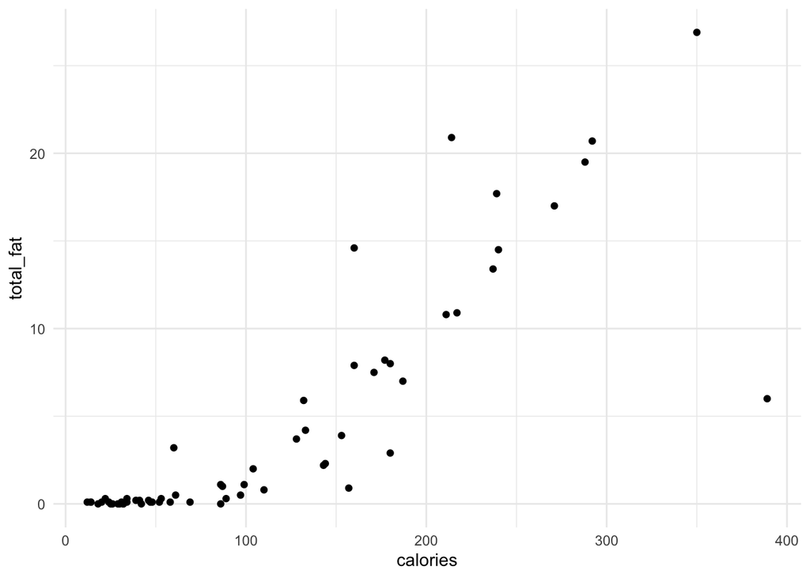

```r
# let's plot those cols from food
food |>
  # call ggplot to start a new plot
  ggplot() +
  # add a layer with points using geom_point
  geom_point(aes(x = calories, y = total_fat)) # define our aes()
```

In the first line we specify the data set (`food`), which is then piped (`|>`) into the function `ggplot`, which instructs R to start a new plot. Next, we add (`+`) a layer to the plot. This layer uses a points geom (`geom_point`) and describes two `aes` values (arguments), `x = calories` and `y = total_fat`.

In order to make a similar plot with different features, or a different data set, you can copy this code and change the associated feature names (`food`, `calories`, and `total_fat`). In the code below create another scatter plot from the food data set, choosing any two features for the two axes:

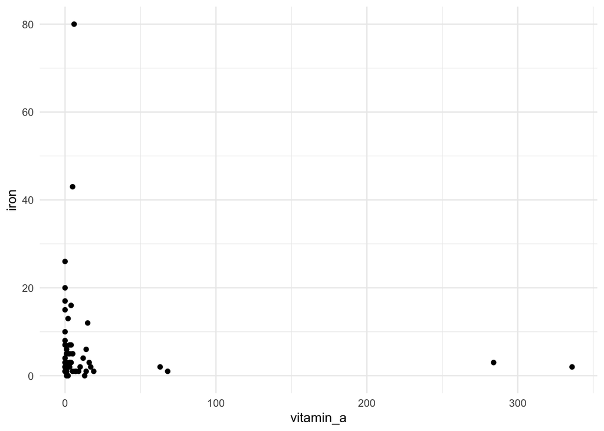

```r
food |>
  ggplot() +
  # note the change in x and y values
  geom_point(aes(x = vitamin_a, y = iron))
```

In the next few classes we will see how to modify and build on this basic structure to create more complex graphics. As a teaser of what’s to come, see how easy it is to add (`+`) custom labels to the plot:

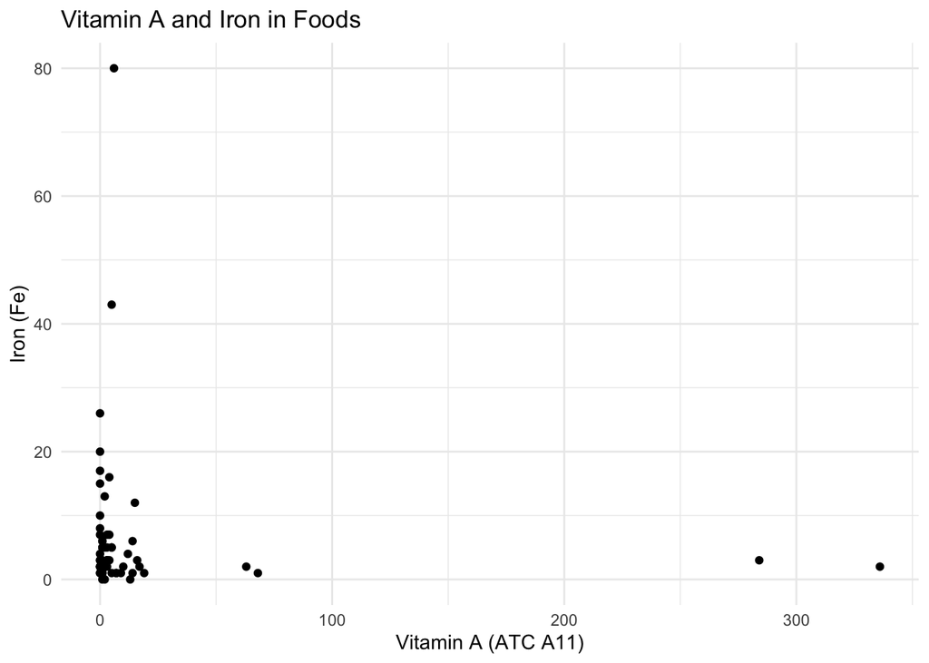

```r
food |>
  ggplot() +
  geom_point(aes(x = vitamin_a, y = iron)) +
  # add labels:
  labs(
    x = "Vitamin A (ATC A11)",
    y = "Iron (Fe)",
    title = "Vitamin A and Iron in Foods"
  )
```

### Text Geometries

Let’s go through several other choices of geometries that we could have in the plot. There are many of these, but in general you can create most plots with only a small number of geometry types. To start, we will use the geometry `geom_text`, which puts a small label in place of the points in our previous example.

The text geometry needs an additional `aes` called `label` to describe what feature in the data set should be used as the label. Here, we use the feature called `item` to label each point with the name of the specific food item in question (the column is called `item`):

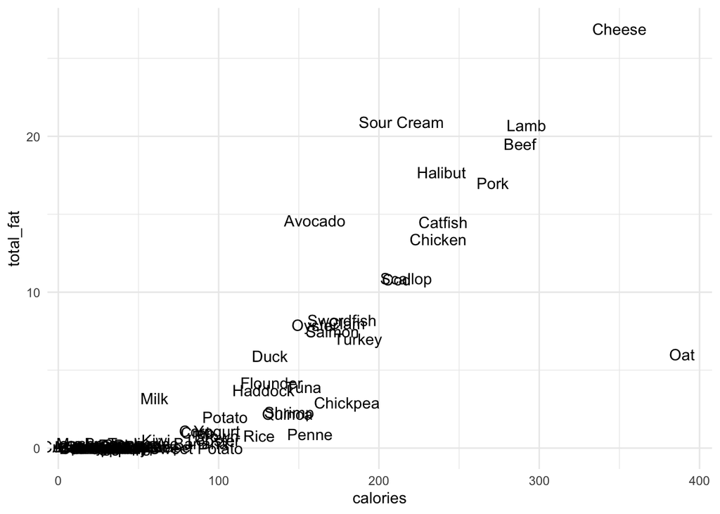

```r
food |>
  ggplot() +
  geom_text(aes(x = calories, y = total_fat, label = item))
```

#### Getting help

Remember, if you want to read more about `geom_text` or any other function, you can search for help from the R console or from `.Rmd` files:

```r
??geom_text
```

You can also find the documentation online by searching for the function name using a few forms:

- `R geom_text`
- `ggplot2 geom_text`
- `geom_text documentation`

`r-project.org` and `tidyverse.org` should be the main websites you check.

### Overlapping text

Can you now identify what food has the highest amount of fat? Or the highest calorie count? Hopefully!

You likely cannot, however, figure out what foods have the lowest amount of fat because the labels become too clumped together.

In order to try to address this issue, we can use a slightly different geometry called `geom_text_repel`. It also places labels on the plot, but has logic that avoids intersecting labels. Instead, labels are moved away from the data points and connected (when needed) by a line segment:

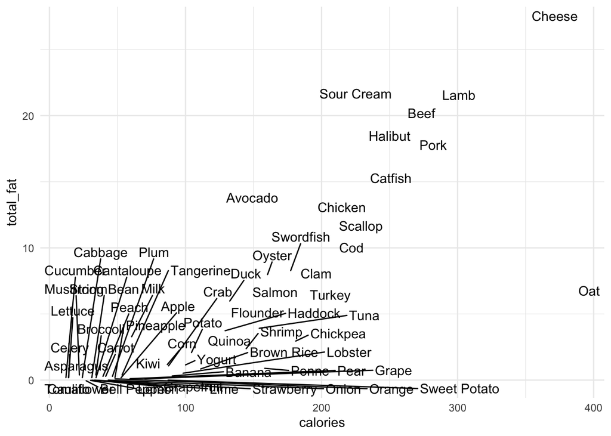

```r
food |>
  ggplot() +
  # note the new geometry
  geom_text_repel(aes(x = calories, y = total_fat, label = item))
```

This is still a bit busy in the lower left-hand corner, but should be slightly easier to read in the middle of the plot.

We can make the plot a bit more readable by adding (`+`) two *layers*, one with the text and another with the points. To do this, just add the two geometries together like this:

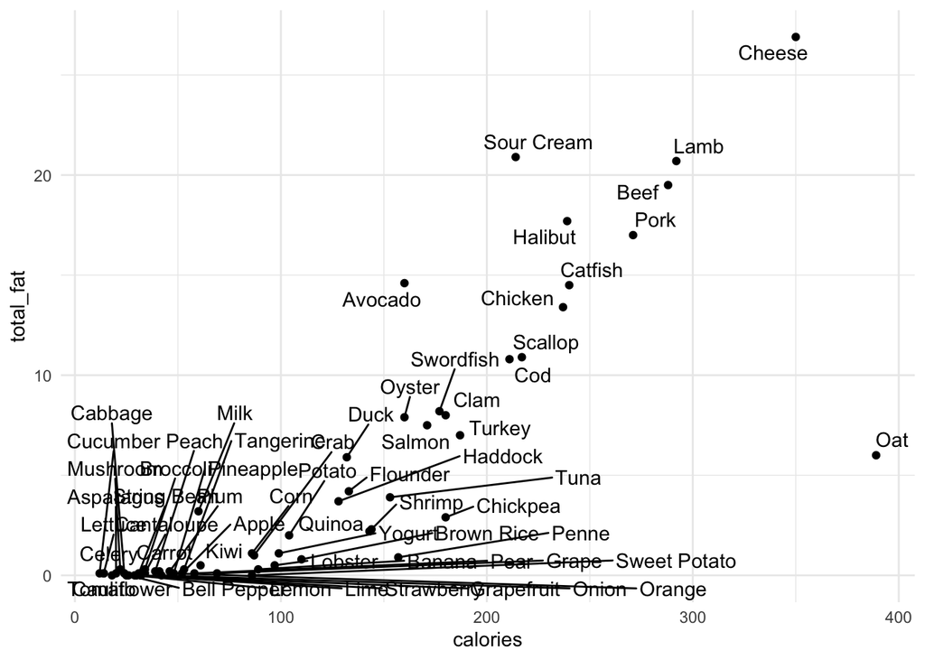

```r
food |>
  ggplot() +
  geom_text_repel(aes(x = calories, y = total_fat, label = item)) +
  # new layer:
  geom_point(aes(x = calories, y = total_fat))
```

Next class we will see how to further improve this plot.

The broader point is that the grammar of graphics allows us to add, subtract, and customize multiple elements of a plot, producing data visualizations iteratively.

### Formatting code

The first notebook stress the importance of following a few style guidelines about your code. Here are additional formatting rules that apply specifically to building graphics in R:

- indent every line that follows a pipe with two extra spaces
- use the pipe operator (`|>`) to connect the data set to the `ggplot` function
- use `+` to add layers to the plot

As with our original set of style guidelines, you will make your life a lot easier if you get used to these rules right from the start. Note that hitting TAB should give you two spaces in the RStudio editor.

While I do not require all of these rules in this class, you should know that these recommendations are derived from the [`tidyverse` style guide](https://style.tidyverse.org/index.html).

## Homework Questions

At at then end of each set of notes, such as this one, will be a short set of questions or activities to complete before the next class. Bring written solutions with you to class.

1. On a piece of paper, create a tabular data set describing five animals of your choosing. The table should have three columns: `name`, `height`, and `weight`. Using any unit of measurement you would like, pick five animals, guess their typical height and weight, and fill in the data.
2. Assume that the data you created above was read into R as an object called `animals`. On a piece of paper, write the R code that would create a labelled scatter plot from your data set with height and weight on the x- and y-axes and the labels giving the name of the animal.
3. Hand-sketch what your scatter plot should look like.
4. Enter the data that you created into a new `.Rmd` file following the example below. (Note that the `c()` function **c**ombines comma-separated values into a vector or list, so the order of the items corresponds to the order of the rows in the tibble or data frame.)

```r
# create your columns by replacing these sample values with your own:
name <- c("elephant", "giraffe", "lion", "tiger", "penguin")
height <- c(3, 5, 1.5, 1.2, 0.5)
weight <- c(5000, 1500, 200, 250, 20)

# create a data frame of your columns
animals <- tibble(name, height, weight)
animals
```

| name | height | weight |
| --- | --- | --- |
| elephant | 3.0 | 5000 |
| giraffe | 5.0 | 1500 |
| lion | 1.5 | 200 |
| tiger | 1.2 | 250 |
| penguin | 0.5 | 20 |

```r
# write in the code that you hand-wrote above here!
```

5. What did you have to change in your handwritten code to make it work as you expected?
6. In these notes, we described how the grammar of graphics describes elements of a plot. List three things about the images in these notes that were NOT directly described by the aesthetics, data, and geometries. Do your best with this; we will discuss in class.